# 1. Data Understanding & Exploration:

```python
#!pip install plotly
```

```python
import numpy as np
import pandas as pd
from sklearn.cluster import KMeans
from sklearn.metrics import silhouette_score
import matplotlib.pyplot as plt
import seaborn as sns
from sklearn.preprocessing import StandardScaler
from kneed import KneeLocator
from sklearn.impute import SimpleImputer
from sklearn.model_selection import train_test_split, GridSearchCV
from sklearn.svm import SVC
from sklearn.metrics import classification_report, confusion_matrix, accuracy_score, roc_auc_score, f1_score
from sklearn.decomposition import PCA
import plotly.express as px
import math as math
import warnings
warnings.filterwarnings('ignore')
```

### A. Read ‘Car name.csv’ as a DataFrame and assign it to a variable

```python
df_car = pd.read_csv('Car name.csv')
df_car.head()
```

|  | car_name |
| --- | --- |
| 0 | chevrolet chevelle malibu |
| 1 | buick skylark 320 |
| 2 | plymouth satellite |
| 3 | amc rebel sst |
| 4 | ford torino |

### B. Read ‘Car-Attributes.json as a DataFrame and assign it to a variable.

```python
df_attr = pd.read_json('Car-Attributes.json')
df_attr.head()
```

|  | mpg | cyl | disp | hp | wt | acc | yr | origin |
| --- | --- | --- | --- | --- | --- | --- | --- | --- |
| 0 | 18.0 | 8 | 307.0 | 130 | 3504 | 12.0 | 70 | 1 |
| 1 | 15.0 | 8 | 350.0 | 165 | 3693 | 11.5 | 70 | 1 |
| 2 | 18.0 | 8 | 318.0 | 150 | 3436 | 11.0 | 70 | 1 |
| 3 | 16.0 | 8 | 304.0 | 150 | 3433 | 12.0 | 70 | 1 |
| 4 | 17.0 | 8 | 302.0 | 140 | 3449 | 10.5 | 70 | 1 |

### C. Merge both the DataFrames together to form a single DataFrame

```python
df_fuel_consmp = df_car.join(df_attr)
```

```python
df_fuel_consmp.head()
```

|  | car_name | mpg | cyl | disp | hp | wt | acc | yr | origin |
| --- | --- | --- | --- | --- | --- | --- | --- | --- | --- |
| 0 | chevrolet chevelle malibu | 18.0 | 8 | 307.0 | 130 | 3504 | 12.0 | 70 | 1 |
| 1 | buick skylark 320 | 15.0 | 8 | 350.0 | 165 | 3693 | 11.5 | 70 | 1 |
| 2 | plymouth satellite | 18.0 | 8 | 318.0 | 150 | 3436 | 11.0 | 70 | 1 |
| 3 | amc rebel sst | 16.0 | 8 | 304.0 | 150 | 3433 | 12.0 | 70 | 1 |
| 4 | ford torino | 17.0 | 8 | 302.0 | 140 | 3449 | 10.5 | 70 | 1 |

### D. Print 5 point summary of the numerical features and share insights.

```python
df_fuel_consmp.describe()
```

|  | mpg | cyl | disp | wt | acc | yr | origin |
| --- | --- | --- | --- | --- | --- | --- | --- |
| count | 398.000000 | 398.000000 | 398.000000 | 398.000000 | 398.000000 | 398.000000 | 398.000000 |
| mean | 23.514573 | 5.454774 | 193.425879 | 2970.424623 | 15.568090 | 76.010050 | 1.572864 |
| std | 7.815984 | 1.701004 | 104.269838 | 846.841774 | 2.757689 | 3.697627 | 0.802055 |
| min | 9.000000 | 3.000000 | 68.000000 | 1613.000000 | 8.000000 | 70.000000 | 1.000000 |
| 25% | 17.500000 | 4.000000 | 104.250000 | 2223.750000 | 13.825000 | 73.000000 | 1.000000 |
| 50% | 23.000000 | 4.000000 | 148.500000 | 2803.500000 | 15.500000 | 76.000000 | 1.000000 |
| 75% | 29.000000 | 8.000000 | 262.000000 | 3608.000000 | 17.175000 | 79.000000 | 2.000000 |
| max | 46.600000 | 8.000000 | 455.000000 | 5140.000000 | 24.800000 | 82.000000 | 3.000000 |

### Insights

#### mpg

```
1. mean and median is almost same i.e 23
2. 25% city-cycle give mpg less than 17.50
3. 50% of city-cycle give less than 23
4 If comparing the difference between max and 75%, max value is huge, there is skewness at the right.
```

#### cyl:

```
1. 25 and 50 percentile of car has less than 4 cyl
2. 75 and max value of car has less than 8 cyl
3. 75 and max percentile are having same value.
4. Mean 5.45 > median 4, Ideally it should be rightly skewned, but 75percentile and max has same value. No skewness should be present.
```

#### disp:

[output not shown]

#### Wt:

[output not shown]

#### Acc:

[output not shown]

#### yr:

[output not shown]

#### origin:

[output not shown]

### 2. Data Preparation & Analysis:

A. Check and print feature-wise percentage of missing values present in the data and impute with the best suitable approach

```python
df_fuel_consmp.shape
```

```
(398, 9)
```

```python
df_fuel_consmp.info()
```

```
<class 'pandas.core.frame.DataFrame'>
RangeIndex: 398 entries, 0 to 397
Data columns (total 9 columns):
 #   Column    Non-Null Count  Dtype
---  ------    --------------  -----
 0   car_name  398 non-null    object
 1   mpg       398 non-null    float64
 2   cyl       398 non-null    int64
 3   disp      398 non-null    float64
 4   hp        398 non-null    object
 5   wt        398 non-null    int64
 6   acc       398 non-null    float64
 7   yr        398 non-null    int64
 8   origin    398 non-null    int64
dtypes: float64(3), int64(4), object(2)
memory usage: 28.1+ KB
```

```python
df_fuel_consmp.isna().sum()*100/len(df_fuel_consmp)
```

```
car_name    0.0
mpg         0.0
cyl         0.0
disp        0.0
hp          0.0
wt          0.0
acc         0.0
yr          0.0
origin      0.0
dtype: float64
```

#### There is no missing value as per the records

Now checking whether there are multiple spaces in the records.

```python
for column in df_fuel_consmp.columns:
    df_fuel_consmp[column] = np.where((df_fuel_consmp[column].astype(str).str.fullmatch(r"\s*")),np.nan,df_fuel_consmp[column])
```

```python
df_fuel_consmp.isna().sum()*100/len(df_fuel_consmp)
```

```
car_name    0.0
mpg         0.0
cyl         0.0
disp        0.0
hp          0.0
wt          0.0
acc         0.0
yr          0.0
origin      0.0
dtype: float64
```

### There is no extra spaces in any of the cell

### If null value is present and impute it with Median Value:

```python
numerics = ['int16', 'int32', 'int64', 'float16', 'float32', 'float64']
for feature in df_fuel_consmp.select_dtypes(include=numerics).columns:
    df_fuel_consmp[feature].fillna(df_fuel_consmp[feature].median(), inplace=True)
```

### B. Check for duplicate values in the data and impute with the best suitable approach.

#### checking for duplicate records in the dataframe.

```python
df_fuel_consmp.duplicated().any()
```

```
False
```

#### Observation: There is no duplicate records present in the dataframe.

#### If there is duplicate element found, then drop it using the below command

```python
def drop_duplicate_if_any(df):
    if df.duplicated().any():
        df.drop_duplicates(inplace=True);
        print('Duplicated Records deleted successfully');
    else:
        print('No Duplicate records found')
```

```python
drop_duplicate_if_any(df_fuel_consmp)
```

```
No Duplicate records found
```

### C. Plot a pairplot for all features.

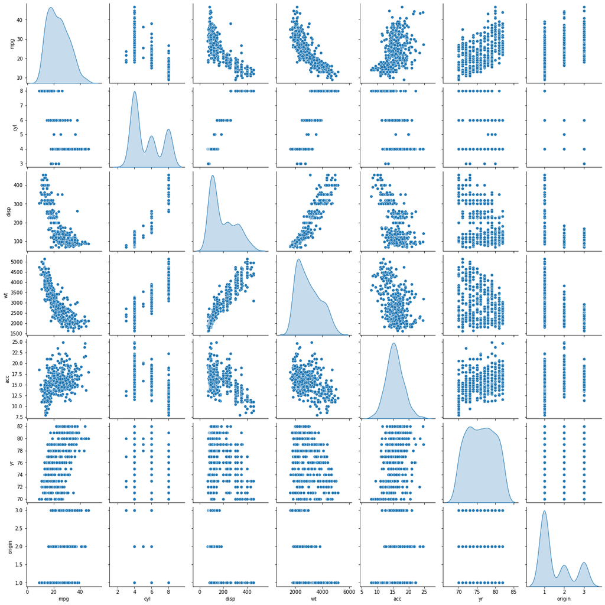

```python
sns.pairplot(df_fuel_consmp, diag_kind='kde');
```

#### Cyc and Mpg, has 3 curve, Minimum cluster we can take is 3 and try it. This is just through visualization. 3 Cluster i think will give good result. Lets see

#### There is cloud in yr , mpg column and acc , mpg. Yr attribute is not useful

### D. Visualize a scatterplot for ‘wt’ and ‘disp’. Datapoints should be distinguishable by ‘cyl’.

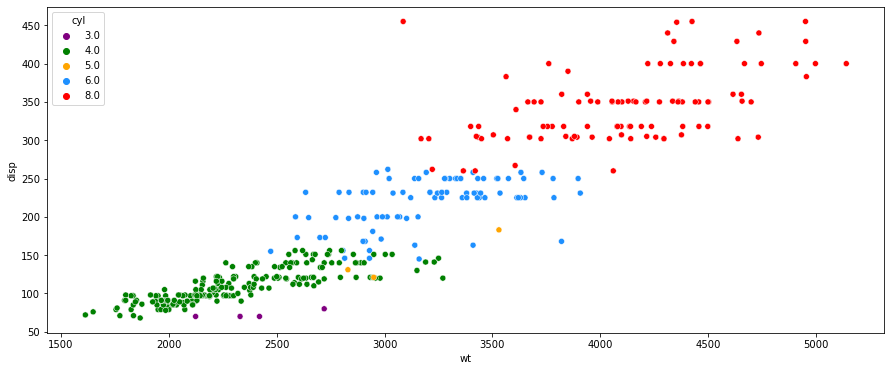

```python
plt.figure(num=1, figsize=(15,6))
sns.scatterplot(data=df_fuel_consmp, x='wt', y='disp', hue='cyl',palette=['purple','green','orange','dodgerblue','red'])
plt.show()
```

### E. Share insights for Q2.d.

#### There is a strong linear relationship between wt and displacement. As the wt is increasing the displacement is increasing.

#### There are some points overlapping of cyl 5 with cyl 4.

#### As the cylinder size is increasing, wt and displacement is also increasing.

### F. Visualize a scatterplot for ‘wt’ and ’mpg’. Datapoints should be distinguishable by ‘cyl’.

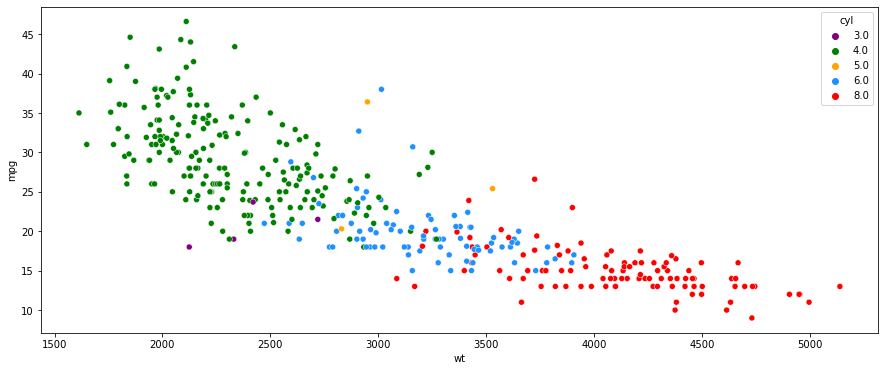

```python
plt.figure(num=1, figsize=(15,6))
sns.scatterplot(data=df_fuel_consmp, x='wt', y='mpg', hue='cyl',palette=['purple','green','orange','dodgerblue','red'])
plt.show()
```

### G. Share insights for Q2.f.

#### There is negative correlation between wt and mpg.

#### The cars whose wt is near 2000, are giving more milega

#### The cars whose wt are around 4000 to 5000 are giving less mpg.

#### Some of the cars who are having 3 cyclinder and wt are around 2200, are giving lesser milega compared to others cars with cyl4

#### Overlapping of different cylinder cars.

### H. Check for unexpected values in all the features and datapoints with such values

```python
def isDigit(x:str):
    try :
        int(x)
        res = True
    except :
        try:
            float(x)
            res = True;
        except:
            res = False
    return res
```

#### Dropping name column, as it is not important feature

```python
df_fuel_consmp.drop(['car_name', 'yr'], axis=1, inplace=True)
```

```python
### Check the catagorial value using the below method
unexpectedValue = dict()
df_fuel_consmp.apply(lambda x :  pd.DataFrame(x).apply(lambda y: unexpectedValue.setdefault(x.name, set()).add(y[0]) if not isDigit(y[0]) else None, axis=1))
print("UnExpected value are " , unexpectedValue)
```

```
UnExpected value are  {'hp': {'?'}}
```

### Dropping all unexepected value

#### Displaying Records with unexpected values for each features

```python
for feature, value in unexpectedValue.items():
    print("Records with expected value in feature '", feature, "'")
    display(df_fuel_consmp[df_fuel_consmp[feature].isin(list(value))])
```

```
Records with expected value in feature ' hp '
```

|  | mpg | cyl | disp | hp | wt | acc | origin |
| --- | --- | --- | --- | --- | --- | --- | --- |
| 32 | 25.0 | 4.0 | 98.0 | ? | 2046.0 | 19.0 | 1.0 |
| 126 | 21.0 | 6.0 | 200.0 | ? | 2875.0 | 17.0 | 1.0 |
| 330 | 40.9 | 4.0 | 85.0 | ? | 1835.0 | 17.3 | 2.0 |
| 336 | 23.6 | 4.0 | 140.0 | ? | 2905.0 | 14.3 | 1.0 |
| 354 | 34.5 | 4.0 | 100.0 | ? | 2320.0 | 15.8 | 2.0 |
| 374 | 23.0 | 4.0 | 151.0 | ? | 3035.0 | 20.5 | 1.0 |

#### Replacing unexpected value with nan and replace it with median

```python
for feature, value in unexpectedValue.items():
    df_fuel_consmp[feature] = df_fuel_consmp[feature].replace(list(value), np.nan)
    df_fuel_consmp[feature].fillna(df_fuel_consmp[feature].median(), inplace=True)
```

```python
df_fuel_consmp.isnull().sum()
```

```
mpg       0
cyl       0
disp      0
hp        0
wt        0
acc       0
origin    0
dtype: int64
```

### Convert categorical column into dummy variables.

```python
df_fuel_consmp = pd.get_dummies(df_fuel_consmp, columns=['origin'], drop_first=True)
```

### Before removing outlier

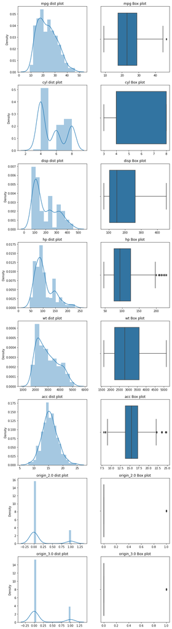

```python
def compareDistBoxPlt(df, y, figXmultiplier, figYMultiplier):
    N = len(y)
    cols =2;
    rows = int(math.ceil(N/cols))
    rows =rows*2
    fig,axs = plt.subplots(nrows=rows, ncols=cols, figsize=(figXmultiplier*rows,figYMultiplier*cols))
    axs = axs.flatten()
    for i, ax in enumerate(axs):
        ax.set_axis_off()
    count = 0
    for i, column in enumerate(y):
        sns.distplot(df[column],ax=axs[count]);
        axs[count].set_title(column+ " dist plot")
        axs[count].set_xlabel("")
        axs[count].set_axis_on()
        count=count+1
        sns.boxplot(data=df, x=column,ax = axs[count]);
        axs[count].set_title(column+ " Box plot")
        axs[count].set_xlabel("")
        axs[count].set_axis_on()
        count=count+1

    plt.show()
compareDistBoxPlt(df_fuel_consmp, df_fuel_consmp.columns, 1.2, 20);
```

### There are less number of outlier present. I can see outliers are present in hp boxplot, acc boxplot and mpg boxplot. All are numerical number.

### KMean is sensitive to outliers. So replacing outliers with median value.

```python
def replaceOutlierWithMedian(df, column):
    q1,q3 = np.quantile(df[column], [0.25,0.75])
    IQR = q3 - q1
    whisker_width = 1.5
    lower_whisker = q1-(1.5*IQR)
    upper_whisker = q3 +(1.5*IQR)
    df[column]=np.where(df[column]>upper_whisker,df[column].median(),np.where(df[column]<lower_whisker,df[column].median(),df[column]))
    print('Outlier replaced from ', column)
```

### Replacing Outliers with Median Value.

```python
for column in ['mpg', 'acc', 'hp']:
    replaceOutlierWithMedian(df_fuel_consmp, column)
```

```
Outlier replaced from  mpg
Outlier replaced from  acc
Outlier replaced from  hp
```

#### Checking the outliers again

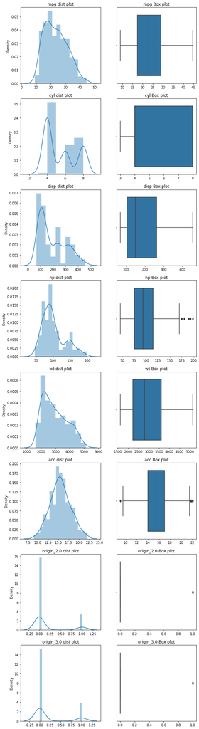

```python
compareDistBoxPlt(df_fuel_consmp, df_fuel_consmp.columns, 1.2, 20);
```

### ### When Outliers will replace with median Values , Distribution become sharper and Standard deviation become lesser. The End result is there might be some outliers which is the result of previous outliers handling. We can live with that small outliiers.

# 3. Clustering

### A. Apply K-Means clustering for 2 to 10 clusters.

#### Before Applying KMEAN , we need to conver the dataset into Scaled dataset.

```python
stdScaler = StandardScaler()
scaled_df = stdScaler.fit_transform(df_fuel_consmp)
scaled_df = pd.DataFrame(scaled_df, columns=df_fuel_consmp.columns)
```

```python
scaled_df.tail(10)
```

|  | mpg | cyl | disp | hp | wt | acc | origin_2.0 | origin_3.0 |
| --- | --- | --- | --- | --- | --- | --- | --- | --- |
| 388 | 0.329639 | -0.856321 | -0.359385 | -0.268568 | -0.455705 | -0.401500 | -0.461968 | -0.497643 |
| 389 | -0.188514 | 0.320935 | 0.370411 | 0.335758 | -0.160119 | -0.321321 | -0.461968 | -0.497643 |
| 390 | 1.106868 | -0.856321 | -0.474616 | -0.147703 | -0.361117 | -0.642037 | -0.461968 | 2.009471 |
| 391 | 1.625021 | -0.856321 | -0.561039 | -0.510298 | -0.709909 | -1.002843 | -0.461968 | -0.497643 |
| 392 | 0.459177 | -0.856321 | -0.407398 | -0.329001 | -0.024149 | 0.721008 | -0.461968 | -0.497643 |
| 393 | 0.459177 | -0.856321 | -0.513026 | -0.449866 | -0.213324 | 0.039485 | -0.461968 | -0.497643 |
| 394 | 2.661327 | -0.856321 | -0.925936 | -1.477219 | -0.993671 | -0.000604 | 2.164651 | -0.497643 |
| 395 | 1.106868 | -0.856321 | -0.561039 | -0.510298 | -0.798585 | -1.564097 | -0.461968 | -0.497643 |
| 396 | 0.588715 | -0.856321 | -0.705077 | -0.661380 | -0.408411 | 1.242172 | -0.461968 | -0.497643 |
| 397 | 0.977330 | -0.856321 | -0.714680 | -0.570731 | -0.296088 | 1.562888 | -0.461968 | -0.497643 |

```python
def calculateKMean(clusters, silhoutette, wss,df):
    for cluster in clusters:
        kmean = KMeans(n_clusters=cluster, init = 'k-means++', random_state = 1);
        kmean.fit(df)
        wss.append(kmean.inertia_)
        silhoutette.append(silhouette_score(df, kmean.labels_))
```

```python
def plotPointPlot(x, y, x_label, y_label, title):
    plt.figure(figsize=(10,6))
    plt.plot(x, y, marker="*")
    plt.xlabel(x_label)
    plt.ylabel(y_label)
    plt.title(title);
    plt.show()
```

```python
clusters = range(2,11)
silhoutette=[]
wss = []
calculateKMean(clusters, silhoutette, wss, scaled_df)
```

### B. Plot a visual and find elbow point.

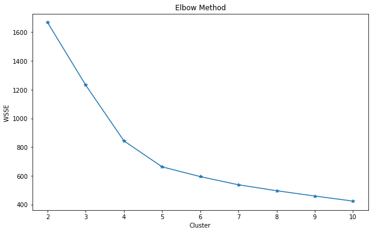

```python
plotPointPlot(clusters, wss, 'Cluster', 'WSSE ', 'Elbow Method')
```

### Looks like there is some bend at 4 and 5. Lets go with Siloutette score and check which cluster is giving maximum

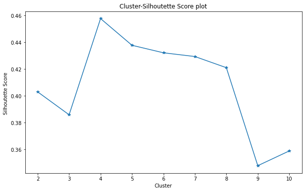

```python
plotPointPlot(clusters, silhoutette, 'Cluster', 'Silhoutette Score ', 'Cluster-Silhoutette Score plot')
```

### C. On the above visual, highlight which are the possible Elbow points.

#### from Above two graph cluster 4 is giving good silohuette score.

### D. Train a K-means clustering model once again on the optimal number of clusters.

```python
optimal_clusters = [3,4,5]
silhoutette=[]
wss = []
calculateKMean(optimal_clusters, silhoutette, wss, scaled_df)
```

### Elbow Method to find elbow point

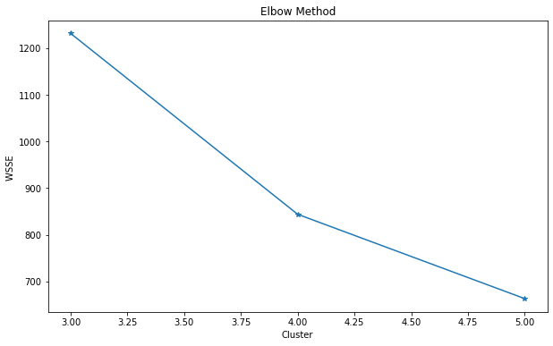

```python
plotPointPlot(optimal_clusters, wss, 'Cluster', 'WSSE ', 'Elbow Method')
```

### from above plot, we can find that there is slow bend at 4. but if we see the silhoutette score, it is maximum at 4, So we will be taking 4 as final cluster

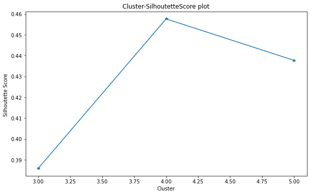

```python
plotPointPlot(optimal_clusters, silhoutette, 'Cluster', 'Silhoutette Score ', 'Cluster-SilhoutetteScore plot')
```

### Silhoutette score is better for 4. So better to take 4 as cluster number

```python
kmean = KMeans(n_clusters=4, init ='k-means++', random_state = 1);
kmean.fit(scaled_df)
label = kmean.predict(scaled_df)
```

### E. Add a new feature in the DataFrame which will have labels based upon cluster value.

```python
scaled_df['cluster'] = label
df_fuel_consmp['cluster'] = label
```

#### Print the Scaled data with cluster

```python
scaled_df.tail(5)
```

|  | mpg | cyl | disp | hp | wt | acc | origin_2.0 | origin_3.0 | cluster |
| --- | --- | --- | --- | --- | --- | --- | --- | --- | --- |
| 393 | 0.459177 | -0.856321 | -0.513026 | -0.449866 | -0.213324 | 0.039485 | -0.461968 | -0.497643 | 0 |
| 394 | 2.661327 | -0.856321 | -0.925936 | -1.477219 | -0.993671 | -0.000604 | 2.164651 | -0.497643 | 3 |
| 395 | 1.106868 | -0.856321 | -0.561039 | -0.510298 | -0.798585 | -1.564097 | -0.461968 | -0.497643 | 0 |
| 396 | 0.588715 | -0.856321 | -0.705077 | -0.661380 | -0.408411 | 1.242172 | -0.461968 | -0.497643 | 0 |
| 397 | 0.977330 | -0.856321 | -0.714680 | -0.570731 | -0.296088 | 1.562888 | -0.461968 | -0.497643 | 0 |

#### Print the Original data with cluster

```python
df_fuel_consmp.head()
```

|  | mpg | cyl | disp | hp | wt | acc | origin_2.0 | origin_3.0 | cluster |
| --- | --- | --- | --- | --- | --- | --- | --- | --- | --- |
| 0 | 18.0 | 8.0 | 307.0 | 130.0 | 3504.0 | 12.0 | 0 | 0 | 1 |
| 1 | 15.0 | 8.0 | 350.0 | 165.0 | 3693.0 | 11.5 | 0 | 0 | 1 |
| 2 | 18.0 | 8.0 | 318.0 | 150.0 | 3436.0 | 11.0 | 0 | 0 | 1 |
| 3 | 16.0 | 8.0 | 304.0 | 150.0 | 3433.0 | 12.0 | 0 | 0 | 1 |
| 4 | 17.0 | 8.0 | 302.0 | 140.0 | 3449.0 | 10.5 | 0 | 0 | 1 |

```python
aggdata=df_fuel_consmp.iloc[:,0:9].groupby('cluster').mean()
aggdata['Freq']=df_fuel_consmp.cluster.value_counts().sort_index()
aggdata
```

| cluster | mpg | cyl | disp | hp | wt | acc | origin_2.0 | origin_3.0 | Freq |
| --- | --- | --- | --- | --- | --- | --- | --- | --- | --- |
| 0 | 23.757823 | 5.047619 | 177.363946 | 90.244898 | 2836.768707 | 16.485714 | 0 | 0 | 147 |
| 1 | 14.788235 | 7.980392 | 344.676471 | 146.230392 | 4118.784314 | 13.020588 | 0 | 0 | 102 |
| 2 | 30.151899 | 4.101266 | 102.708861 | 79.835443 | 2221.227848 | 16.172152 | 0 | 1 | 79 |
| 3 | 27.891429 | 4.157143 | 109.142857 | 80.928571 | 2423.300000 | 16.292857 | 1 | 0 | 70 |

### F. Plot a visual and color the datapoints based upon clusters.

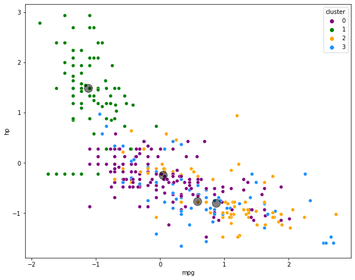

```python
#plotting the clusters
plt.figure(figsize=(10, 8))
sns.scatterplot(x="mpg", y="hp", hue="cluster",data=scaled_df, palette=['purple','green','orange','dodgerblue']);
centers = kmean.cluster_centers_
plt.scatter(centers[:, 0], centers[:, 1], c='black', s=200, alpha=0.5);
```

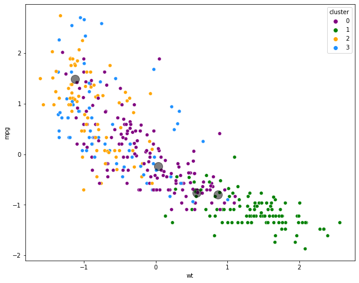

```python
#plotting the clusters
plt.figure(figsize=(10, 8))
sns.scatterplot(x="wt", y="mpg", hue="cluster",data=scaled_df, palette=['purple','green','orange','dodgerblue']);
centers = kmean.cluster_centers_
plt.scatter(centers[:, 0], centers[:, 1], c='black', s=200, alpha=0.5);
```

### G. Pass a new DataPoint and predict which cluster it belongs to.

#### Lets create a Random point and scale it using the same scaler through which we scaled the trained data.

```python
from scipy.spatial.distance import cdist
new_point = [[21, 5.0, 150.0, 88, 2569, 16,0,0]]
df_new_point =pd.DataFrame(new_point, columns=df_fuel_consmp.columns.drop('cluster'))
scaled_new_point = stdScaler.transform(new_point)
```

### Finding the minimum distance of new points from centroid

```python
distance = cdist(scaled_new_point, kmean.cluster_centers_, 'euclidean')
print('Distance of new datapoint from each centroid ', distance)
min_distance_centroid = np.where(distance[0] == np.min(distance))
print(f'Centroid {min_distance_centroid[0]} is very closed to the new data point. Distance is {np.min(distance)}')
```

```
Distance of new datapoint from each centroid  [[0.5832695  3.88586869 2.90032175 2.8609848 ]]
Centroid [0] is very closed to the new data point. Distance is 0.5832695029554602
```

#### Predicting the same point with Model KMEAN

```python
y_pre = kmean.predict(scaled_new_point)
y_pre
```

```
array([0])
```

```python
print(f'New Data point belongs to {y_pre} cluster')
```

```
New Data point belongs to [0] cluster
```

### From the above prediction, the new data point is assigned to cluster 0.

# PART B

### 1. Data Understanding & Cleaning

### A. Read ‘vehicle.csv’ and save as DataFrame

```python
df_vehicle = pd.read_csv('vehicle.csv')
df_vehicle.head()
```

|  | compactness | circularity | distance_circularity | radius_ratio | pr.axis_aspect_ratio | max.length_aspect_ratio | scatter_ratio | elongatedness | pr.axis_rectangularity | max.length_rectangularity | scaled_variance | scaled_variance.1 | scaled_radius_of_gyration | scaled_radius_of_gyration.1 | skewness_about | skewness_about.1 | skewness_about.2 | hollows_ratio | class |
| --- | --- | --- | --- | --- | --- | --- | --- | --- | --- | --- | --- | --- | --- | --- | --- | --- | --- | --- | --- |
| 0 | 95 | 48.0 | 83.0 | 178.0 | 72.0 | 10 | 162.0 | 42.0 | 20.0 | 159 | 176.0 | 379.0 | 184.0 | 70.0 | 6.0 | 16.0 | 187.0 | 197 | van |
| 1 | 91 | 41.0 | 84.0 | 141.0 | 57.0 | 9 | 149.0 | 45.0 | 19.0 | 143 | 170.0 | 330.0 | 158.0 | 72.0 | 9.0 | 14.0 | 189.0 | 199 | van |
| 2 | 104 | 50.0 | 106.0 | 209.0 | 66.0 | 10 | 207.0 | 32.0 | 23.0 | 158 | 223.0 | 635.0 | 220.0 | 73.0 | 14.0 | 9.0 | 188.0 | 196 | car |
| 3 | 93 | 41.0 | 82.0 | 159.0 | 63.0 | 9 | 144.0 | 46.0 | 19.0 | 143 | 160.0 | 309.0 | 127.0 | 63.0 | 6.0 | 10.0 | 199.0 | 207 | van |
| 4 | 85 | 44.0 | 70.0 | 205.0 | 103.0 | 52 | 149.0 | 45.0 | 19.0 | 144 | 241.0 | 325.0 | 188.0 | 127.0 | 9.0 | 11.0 | 180.0 | 183 | bus |

```python
df_vehicle.info()
```

```
<class 'pandas.core.frame.DataFrame'>
RangeIndex: 846 entries, 0 to 845
Data columns (total 19 columns):
 #   Column                       Non-Null Count  Dtype
---  ------                       --------------  -----
 0   compactness                  846 non-null    int64
 1   circularity                  841 non-null    float64
 2   distance_circularity         842 non-null    float64
 3   radius_ratio                 840 non-null    float64
 4   pr.axis_aspect_ratio         844 non-null    float64
 5   max.length_aspect_ratio      846 non-null    int64
 6   scatter_ratio                845 non-null    float64
 7   elongatedness                845 non-null    float64
 8   pr.axis_rectangularity       843 non-null    float64
 9   max.length_rectangularity    846 non-null    int64
 10  scaled_variance              843 non-null    float64
 11  scaled_variance.1            844 non-null    float64
 12  scaled_radius_of_gyration    844 non-null    float64
 13  scaled_radius_of_gyration.1  842 non-null    float64
 14  skewness_about               840 non-null    float64
 15  skewness_about.1             845 non-null    float64
 16  skewness_about.2             845 non-null    float64
 17  hollows_ratio                846 non-null    int64
 18  class                        846 non-null    object
dtypes: float64(14), int64(4), object(1)
memory usage: 125.7+ KB
```

### There is only column which is object type. This is a target variable. Other than Target, everything is int or float

### B. Check percentage of missing values and impute with correct approach.

```python
(df_vehicle.isna().sum()/len(df_vehicle))*100
```

```
compactness                    0.000000
circularity                    0.591017
distance_circularity           0.472813
radius_ratio                   0.709220
pr.axis_aspect_ratio           0.236407
max.length_aspect_ratio        0.000000
scatter_ratio                  0.118203
elongatedness                  0.118203
pr.axis_rectangularity         0.354610
max.length_rectangularity      0.000000
scaled_variance                0.354610
scaled_variance.1              0.236407
scaled_radius_of_gyration      0.236407
scaled_radius_of_gyration.1    0.472813
skewness_about                 0.709220
skewness_about.1               0.118203
skewness_about.2               0.118203
hollows_ratio                  0.000000
class                          0.000000
dtype: float64
```

#### Obersvation : Sum of missing value for each feature is described above. Let impute it

```python
df_vehicle.describe()
```

|  | compactness | circularity | distance_circularity | radius_ratio | pr.axis_aspect_ratio | max.length_aspect_ratio | scatter_ratio | elongatedness | pr.axis_rectangularity | max.length_rectangularity | scaled_variance | scaled_variance.1 | scaled_radius_of_gyration | scaled_radius_of_gyration.1 | skewness_about | skewness_about.1 | skewness_about.2 | hollows_ratio |
| --- | --- | --- | --- | --- | --- | --- | --- | --- | --- | --- | --- | --- | --- | --- | --- | --- | --- | --- |
| count | 846.000000 | 841.000000 | 842.000000 | 840.000000 | 844.000000 | 846.000000 | 845.000000 | 845.000000 | 843.000000 | 846.000000 | 843.000000 | 844.000000 | 844.000000 | 842.000000 | 840.000000 | 845.000000 | 845.000000 | 846.000000 |
| mean | 93.678487 | 44.828775 | 82.110451 | 168.888095 | 61.678910 | 8.567376 | 168.901775 | 40.933728 | 20.582444 | 147.998818 | 188.631079 | 439.494076 | 174.709716 | 72.447743 | 6.364286 | 12.602367 | 188.919527 | 195.632388 |
| std | 8.234474 | 6.152172 | 15.778292 | 33.520198 | 7.891463 | 4.601217 | 33.214848 | 7.816186 | 2.592933 | 14.515652 | 31.411004 | 176.666903 | 32.584808 | 7.486190 | 4.920649 | 8.936081 | 6.155809 | 7.438797 |
| min | 73.000000 | 33.000000 | 40.000000 | 104.000000 | 47.000000 | 2.000000 | 112.000000 | 26.000000 | 17.000000 | 118.000000 | 130.000000 | 184.000000 | 109.000000 | 59.000000 | 0.000000 | 0.000000 | 176.000000 | 181.000000 |
| 25% | 87.000000 | 40.000000 | 70.000000 | 141.000000 | 57.000000 | 7.000000 | 147.000000 | 33.000000 | 19.000000 | 137.000000 | 167.000000 | 318.000000 | 149.000000 | 67.000000 | 2.000000 | 5.000000 | 184.000000 | 190.250000 |
| 50% | 93.000000 | 44.000000 | 80.000000 | 167.000000 | 61.000000 | 8.000000 | 157.000000 | 43.000000 | 20.000000 | 146.000000 | 179.000000 | 363.500000 | 173.500000 | 71.500000 | 6.000000 | 11.000000 | 188.000000 | 197.000000 |
| 75% | 100.000000 | 49.000000 | 98.000000 | 195.000000 | 65.000000 | 10.000000 | 198.000000 | 46.000000 | 23.000000 | 159.000000 | 217.000000 | 587.000000 | 198.000000 | 75.000000 | 9.000000 | 19.000000 | 193.000000 | 201.000000 |
| max | 119.000000 | 59.000000 | 112.000000 | 333.000000 | 138.000000 | 55.000000 | 265.000000 | 61.000000 | 29.000000 | 188.000000 | 320.000000 | 1018.000000 | 268.000000 | 135.000000 | 22.000000 | 41.000000 | 206.000000 | 211.000000 |

### Observation : There is no categorical column. So mode is not applicable for any of the column. We can replace null value with median value

```python
imputer = SimpleImputer(missing_values = np.nan,strategy ='median')
imputer = imputer.fit(df_vehicle.iloc[:,0:18])
df_vehicle.iloc[:,0:18] = imputer.transform(df_vehicle.iloc[:,0:18])
df_vehicle
```

|  | compactness | circularity | distance_circularity | radius_ratio | pr.axis_aspect_ratio | max.length_aspect_ratio | scatter_ratio | elongatedness | pr.axis_rectangularity | max.length_rectangularity | scaled_variance | scaled_variance.1 | scaled_radius_of_gyration | scaled_radius_of_gyration.1 | skewness_about | skewness_about.1 | skewness_about.2 | hollows_ratio | class |
| --- | --- | --- | --- | --- | --- | --- | --- | --- | --- | --- | --- | --- | --- | --- | --- | --- | --- | --- | --- |
| 0 | 95.0 | 48.0 | 83.0 | 178.0 | 72.0 | 10.0 | 162.0 | 42.0 | 20.0 | 159.0 | 176.0 | 379.0 | 184.0 | 70.0 | 6.0 | 16.0 | 187.0 | 197.0 | van |
| 1 | 91.0 | 41.0 | 84.0 | 141.0 | 57.0 | 9.0 | 149.0 | 45.0 | 19.0 | 143.0 | 170.0 | 330.0 | 158.0 | 72.0 | 9.0 | 14.0 | 189.0 | 199.0 | van |
| 2 | 104.0 | 50.0 | 106.0 | 209.0 | 66.0 | 10.0 | 207.0 | 32.0 | 23.0 | 158.0 | 223.0 | 635.0 | 220.0 | 73.0 | 14.0 | 9.0 | 188.0 | 196.0 | car |
| 3 | 93.0 | 41.0 | 82.0 | 159.0 | 63.0 | 9.0 | 144.0 | 46.0 | 19.0 | 143.0 | 160.0 | 309.0 | 127.0 | 63.0 | 6.0 | 10.0 | 199.0 | 207.0 | van |
| 4 | 85.0 | 44.0 | 70.0 | 205.0 | 103.0 | 52.0 | 149.0 | 45.0 | 19.0 | 144.0 | 241.0 | 325.0 | 188.0 | 127.0 | 9.0 | 11.0 | 180.0 | 183.0 | bus |
| ... | ... | ... | ... | ... | ... | ... | ... | ... | ... | ... | ... | ... | ... | ... | ... | ... | ... | ... | ... |
| 841 | 93.0 | 39.0 | 87.0 | 183.0 | 64.0 | 8.0 | 169.0 | 40.0 | 20.0 | 134.0 | 200.0 | 422.0 | 149.0 | 72.0 | 7.0 | 25.0 | 188.0 | 195.0 | car |
| 842 | 89.0 | 46.0 | 84.0 | 163.0 | 66.0 | 11.0 | 159.0 | 43.0 | 20.0 | 159.0 | 173.0 | 368.0 | 176.0 | 72.0 | 1.0 | 20.0 | 186.0 | 197.0 | van |
| 843 | 106.0 | 54.0 | 101.0 | 222.0 | 67.0 | 12.0 | 222.0 | 30.0 | 25.0 | 173.0 | 228.0 | 721.0 | 200.0 | 70.0 | 3.0 | 4.0 | 187.0 | 201.0 | car |
| 844 | 86.0 | 36.0 | 78.0 | 146.0 | 58.0 | 7.0 | 135.0 | 50.0 | 18.0 | 124.0 | 155.0 | 270.0 | 148.0 | 66.0 | 0.0 | 25.0 | 190.0 | 195.0 | car |
| 845 | 85.0 | 36.0 | 66.0 | 123.0 | 55.0 | 5.0 | 120.0 | 56.0 | 17.0 | 128.0 | 140.0 | 212.0 | 131.0 | 73.0 | 1.0 | 18.0 | 186.0 | 190.0 | van |

846 rows × 19 columns

#### Checking whether null value is replaced by median or not and check the missing value in the dataset again

```python
(df_vehicle.isna().sum()/len(df_vehicle))*100
```

```
compactness                    0.0
circularity                    0.0
distance_circularity           0.0
radius_ratio                   0.0
pr.axis_aspect_ratio           0.0
max.length_aspect_ratio        0.0
scatter_ratio                  0.0
elongatedness                  0.0
pr.axis_rectangularity         0.0
max.length_rectangularity      0.0
scaled_variance                0.0
scaled_variance.1              0.0
scaled_radius_of_gyration      0.0
scaled_radius_of_gyration.1    0.0
skewness_about                 0.0
skewness_about.1               0.0
skewness_about.2               0.0
hollows_ratio                  0.0
class                          0.0
dtype: float64
```

#### All the nan null are replaced with median value

### C. Visualize a Pie-chart and print percentage of values for variable ‘class’.

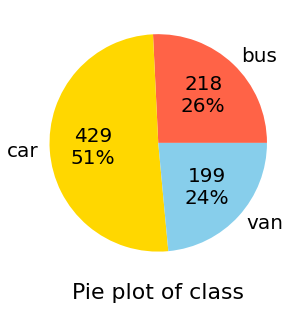

```python
def label_function(val):
    return f'{val / 100 * len(df_vehicle):.0f}\n{val:.0f}%'

N = 50
fig, (ax1) = plt.subplots(ncols=1, figsize=(20, 5))
df_vehicle.groupby('class').size().plot(kind='pie', autopct=label_function, textprops={'fontsize': 20},
                                  colors=['tomato', 'gold', 'skyblue'], ax=ax1)
ax1.set_xlabel('Pie plot of class', size=22)
ax1.set_ylabel('')
plt.show()
```

### Looks like the data is not balanced.

#### Car has 51 % data, bus having 26 and van has 24%

### D. Check for duplicate rows in the data and impute with correct approach.

### Check for duplicate rows

```python
df_vehicle.duplicated().any()
```

```
False
```

#### Obersvation: There is no duplicate row present in the dataframe.

### If there is duplicate row, the next cell will remove it.

```python
if df_vehicle.duplicated().any():
    df_vehicle.drop_duplicates(inplace=True);
    print('Duplicate rows Removed')
else:
    print('No Duplicate Records found')
```

```
No Duplicate Records found
```

### Visualisation and Removing Outliers

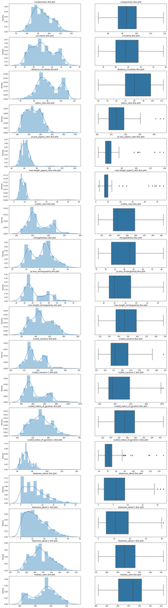

```python
compareDistBoxPlt(df_vehicle, df_vehicle.columns.drop('class'), 1,35);
```

### From the above Plots, we can clearly see that there are outliers present in the features. PCA, SVM are sensitive to outliers .Lets fix the outlier issue and estimate the model

### Replacing outliers with Median value

```python
for column in df_vehicle.columns.drop('class'):
    replaceOutlierWithMedian(df_vehicle, column)
```

```
Outlier replaced from  compactness
Outlier replaced from  circularity
Outlier replaced from  distance_circularity
Outlier replaced from  radius_ratio
Outlier replaced from  pr.axis_aspect_ratio
Outlier replaced from  max.length_aspect_ratio
Outlier replaced from  scatter_ratio
Outlier replaced from  elongatedness
Outlier replaced from  pr.axis_rectangularity
Outlier replaced from  max.length_rectangularity
Outlier replaced from  scaled_variance
Outlier replaced from  scaled_variance.1
Outlier replaced from  scaled_radius_of_gyration
Outlier replaced from  scaled_radius_of_gyration.1
Outlier replaced from  skewness_about
Outlier replaced from  skewness_about.1
Outlier replaced from  skewness_about.2
Outlier replaced from  hollows_ratio
```

### Plot and check each features

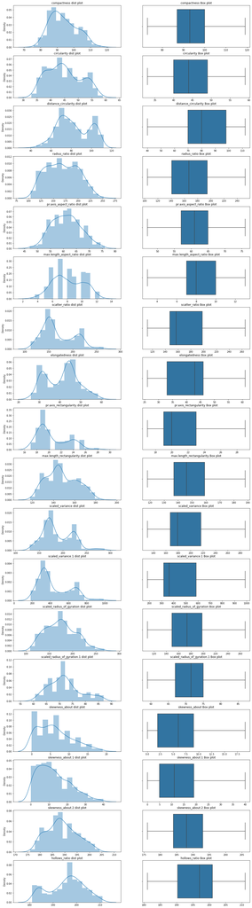

```python
compareDistBoxPlt(df_vehicle, df_vehicle.columns.drop('class'), 1,35);
```

### Previous Outliers have been removed but when outliers are removed with Median value, distribution become sharper and standard deviation become less compared to original value, So it might again give some outliers. But this outliers are acceptable because its come with the result of previous handling of outliers.

# 2. Data Preparation:

#### A. Split data into X and Y.

```python
from imblearn.over_sampling import SMOTE
sm = SMOTE(random_state = 42)
```

```python
X = df_vehicle.drop('class', axis=1);
y = df_vehicle[['class']]
y = y.replace({'bus':0,'car':1, 'van':2})
X_train, X_test, y_train, y_test = train_test_split(X,y,test_size=0.3, random_state=42, stratify=y)
X_train_balance, y_train_balance = sm.fit_resample(X_train, y_train)
```

### B. Standardize the Data.

```python
stdScaler = StandardScaler()
X_train_bal_scle = stdScaler.fit_transform(X_train_balance)
X_test_bal_scle = stdScaler.transform(X_test)
```

### 3. Model Building:

### A. Train a base Classification model using SVM.

#### Train SVC model with balance dataset

```python
svc = SVC(random_state=42, probability=True)
svc.fit(X_train_bal_scle, y_train_balance)
y_pred_bal_scle = svc.predict(X_test_bal_scle)
```

### B. Print Classification metrics for train data.

#### Accuracy of Train data

```python
train_accuracy = svc.score(X_train_bal_scle, y_train_balance)
train_accuracy
```

```
0.9811111111111112
```

#### Accuracy of Test data

```python
test_accuracy = svc.score(X_test_bal_scle, y_test)
test_accuracy
```

```
0.9448818897637795
```

### AUC Score

```python
predictions_proba = svc.predict_proba(X_test_bal_scle)
auc = roc_auc_score(y_test, predictions_proba,multi_class='ovr')
auc
```

```
0.9955213106330344
```

#### Confusion matrix

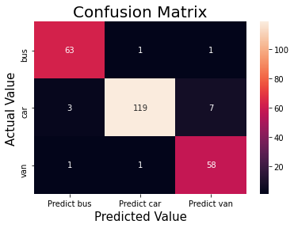

```python
cm = confusion_matrix(y_test, y_pred_bal_scle, labels=[0,1,2])
# Printing the precision and recall, among other metrics
df_cm = pd.DataFrame(cm, index = [i for i in ['bus', 'car', 'van']],
                  columns = ["Predict "+ str(i) for i in ['bus', 'car', 'van']])
ax = plt.axes()
sns.heatmap(df_cm, annot=True, fmt='g');
plt.title('Confusion Matrix', fontsize = 20) # title with fontsize 20
plt.xlabel('Predicted Value', fontsize = 15) # x-axis label with fontsize 15
plt.ylabel('Actual Value', fontsize = 15);
```

#### Classification Report

```python
print(classification_report(y_test, y_pred_bal_scle, labels=[0,1,2]))
```

```
              precision    recall  f1-score   support

           0       0.94      0.97      0.95        65
           1       0.98      0.92      0.95       129
           2       0.88      0.97      0.92        60

    accuracy                           0.94       254
   macro avg       0.93      0.95      0.94       254
weighted avg       0.95      0.94      0.95       254
```

### F1 Score

```python
f1 = f1_score(y_test, y_pred_bal_scle,average="weighted")
```

```python
result = []
result.append(['SVC with Balanced Scaled Data', train_accuracy, test_accuracy, auc, f1])
```

### C. Apply PCA on the data with 10 components.

#### Scale the dataset

```python
pca_stdScaler = StandardScaler()
X_scaled = pca_stdScaler.fit_transform(X)
```

#### Take only 10 PCA

```python
n_components=10
pca =PCA(n_components=n_components)
pca.fit(X_scaled)
```

```
PCA(n_components=10)
```

#### How much variance explained each PCA in %

```python
print("Explain variance ratio ", pca.explained_variance_ratio_)
```

```
Explain variance ratio  [0.54099325 0.18593103 0.06616512 0.0629155  0.04905291 0.03697101
 0.01765416 0.01266163 0.00727021 0.00443153]
```

```python
print("Explain variance ", pca.explained_variance_)
```

```
Explain variance  [9.74940269 3.35071912 1.19238155 1.13381916 0.88399731 0.66626575
 0.31815091 0.22817914 0.1310186  0.07986191]
```

#### Eigen vectors

```python
print("Component", pca.components_)
```

```
Component [[ 0.27250289  0.28725469  0.30242111  0.26971354  0.09786073  0.19520014
   0.31052393 -0.3090069   0.307287    0.27815416  0.29976509  0.30553237
   0.26323762 -0.04193594  0.03608321  0.05872048  0.03801314  0.08474   ]
 [-0.08704358  0.13162176 -0.04614301 -0.19793126 -0.25783995 -0.10804563
   0.07528535 -0.01322994  0.0875602   0.12215424  0.07726575  0.07150302
   0.21058205  0.50362158 -0.01576632 -0.09274624 -0.50162122 -0.50761211]
 [-0.03818521 -0.20114691  0.06346211  0.05628517 -0.06199275 -0.14895782
   0.10904283 -0.09085269  0.1060705  -0.21368469  0.1445998   0.11034374
  -0.20287019  0.07386402 -0.55917399  0.6706805  -0.06224071 -0.04170535]
 [ 0.13867501 -0.03805548  0.10895429 -0.25435509 -0.61276572  0.27867816
   0.00539295  0.06521486  0.03089915  0.04146747 -0.06400509 -0.00219687
  -0.08553965 -0.11539962  0.47370331  0.42842603 -0.0274096   0.09603749]
 [ 0.13710147 -0.13899555 -0.08001743  0.13374437  0.12360146 -0.63489336
   0.08555745 -0.07907344  0.08164638 -0.25111294  0.14747123  0.11010098
  -0.00521211  0.1380686   0.56655224  0.13086982  0.18051929 -0.11078807]
 [ 0.26361138 -0.07134742 -0.01690062 -0.13818365 -0.57782861 -0.289097
   0.09774711 -0.07572829  0.10540323 -0.07819621  0.1329124   0.11539822
  -0.0670574  -0.13151308 -0.31917609 -0.46840497  0.28013644  0.05944441]
 [ 0.20271711 -0.39227536  0.16337128  0.16191053  0.09276331  0.39826629
   0.09235194 -0.1040706   0.09313178 -0.35456434  0.06805461  0.09011943
  -0.45529272  0.08582268  0.12453218 -0.3025177  -0.25825026 -0.17326923]
 [-0.75879641 -0.06760342  0.27737195  0.11054475 -0.18685876 -0.0462188
   0.06462042 -0.19234282  0.01386846 -0.21516342  0.19567872  0.03779482
   0.14675266 -0.330395    0.1142554  -0.11540387 -0.09465996 -0.00649718]
 [ 0.36668592  0.05532619  0.07467849  0.26666667 -0.03862966 -0.13716337
  -0.13156766  0.28963351 -0.0895291  -0.15823198  0.04270347 -0.15107267
   0.26377133 -0.55526717 -0.05990393  0.05238458 -0.37916894 -0.28034051]
 [-0.16004522  0.18232396 -0.27303378  0.05059872  0.03430379 -0.1779608
   0.14313264  0.07938311  0.2398967   0.38273948 -0.16609091  0.28745769
  -0.54962653 -0.3625473   0.05798919 -0.01289953 -0.18784852 -0.13340267]]
```

#### Plotting how each PCA show variance of data

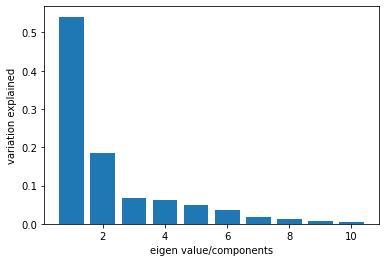

```python
plt.bar(list(range(1,n_components+1)), pca.explained_variance_ratio_)
plt.xlabel("eigen value/components")
plt.ylabel("variation explained")
plt.show()
```

### D. Visualize Cumulative Variance Explained with Number of Components.

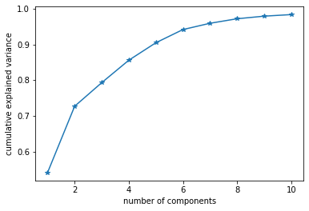

```python
plt.plot(list(range(1,n_components+1)), np.cumsum(pca.explained_variance_ratio_), marker= "*")
plt.xlabel('number of components')
plt.ylabel('cumulative explained variance');
```

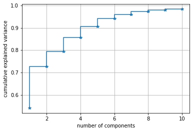

```python
plt.step(list(range(1,11)),np.cumsum(pca.explained_variance_ratio_), marker= "*")
plt.xlabel('number of components')
plt.ylabel('cumulative explained variance');
plt.grid()
```

### E. Draw a horizontal line on the above plot to highlight the threshold of 90%.

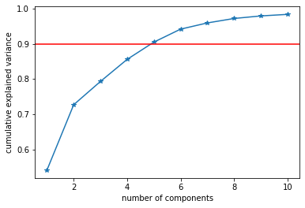

```python
plt.plot(list(range(1,n_components+1)),np.cumsum(pca.explained_variance_ratio_), marker= "*")
plt.axhline(y=0.9, color='r', linestyle='-')
plt.xlabel('number of components')
plt.ylabel('cumulative explained variance');
```

#### From the above plot, 90% of variance is derived from 5 PC components. and 95% of variance is covered by 7 PC components

### F. Apply PCA on the data. This time Select Minimum Components with 90% or above variance explained.

```python
n_components=5
pca =PCA(n_components=n_components)
pca_X = pca.fit_transform(X_scaled)
```

```python
pca.explained_variance_ratio_
```

```
array([0.54099325, 0.18593103, 0.06616512, 0.0629155 , 0.04905291])
```

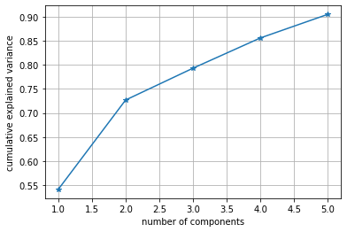

```python
plt.plot(list(range(1,n_components+1)),np.cumsum(pca.explained_variance_ratio_), marker= "*")
plt.xlabel('number of components')
plt.ylabel('cumulative explained variance');
plt.grid()
```

### G. Train SVM model on components selected from above step

```python
X_train_pca, X_test_pca, y_train_pca, y_test_pca = train_test_split(pca_X, y,test_size=0.3,random_state=42, stratify=y)
X_train_pca_balance, y_train_pca_balance = sm.fit_resample(X_train_pca, y_train_pca)
```

```python
svc = SVC(random_state=42, probability=True,C=1)
svc.fit(X_train_pca_balance, y_train_pca_balance.values.ravel())
y_pred_pca = svc.predict(X_test_pca)
```

### H. Print Classification metrics for train data of above model and share insights.

### Training Accuracy

```python
train_accuracy= svc.score(X_train_pca_balance, y_train_pca_balance)
train_accuracy
```

```
0.9244444444444444
```

### Testing Accuracy

```python
test_accuracy= svc.score(X_test_pca, y_test_pca)
test_accuracy
```

```
0.8818897637795275
```

### AUC SCORE

```python
auc = roc_auc_score(y_test_pca, svc.predict_proba(X_test_pca), multi_class="ovr")
auc
```

```
0.9780237790955445
```

### Confusion Metric

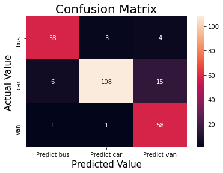

```python
cm = confusion_matrix(y_test_pca, y_pred_pca, labels=[0,1,2])
# Printing the precision and recall, among other metrics
df_cm = pd.DataFrame(cm, index = [i for i in ['bus', 'car', 'van']],
                  columns = ["Predict "+ str(i) for i in ['bus', 'car', 'van']])
sns.heatmap(df_cm, annot=True, fmt='g');
plt.title('Confusion Matrix', fontsize = 20); # title with fontsize 20
plt.xlabel('Predicted Value', fontsize = 15); # x-axis label with fontsize 15
plt.ylabel('Actual Value', fontsize = 15);
```

### Classification Report

```python
print(classification_report(y_test_pca, y_pred_pca, labels=[0,1,2]))
```

```
              precision    recall  f1-score   support

           0       0.89      0.89      0.89        65
           1       0.96      0.84      0.90       129
           2       0.75      0.97      0.85        60

    accuracy                           0.88       254
   macro avg       0.87      0.90      0.88       254
weighted avg       0.90      0.88      0.88       254
```

### f1 Score

```python
f1 = f1_score(y_test_pca, y_pred_pca,average="weighted")
```

### The model is base, we have not done optimisation yet.

```python
result.append(['SVC with Balanced PCA', train_accuracy, test_accuracy,auc, f1])
```

### 4. Performance Improvement:

### A. Train another SVM on the components out of PCA. Tune the parameters to improve performance

```python
param_grid = {'C': [0.5,1,2,3,4],
              'gamma': [0.8,0.7,0.6,0.5],
             'kernel':['rbf']}
clf = GridSearchCV(SVC(random_state=42, probability=True),
                   param_grid, cv=10,refit=True,verbose=2,n_jobs =-1)
clf = clf.fit(X_train_pca_balance, y_train_pca_balance.values.ravel())
print("Best estimator found by grid search:")
print(clf.best_estimator_)
```

```
Fitting 10 folds for each of 20 candidates, totalling 200 fits
Best estimator found by grid search:
SVC(C=2, gamma=0.6, probability=True, random_state=42)
```

### B. Share best Parameters observed from above step.

```python
print("Best Parameter value is ", clf.best_params_)
```

```
Best Parameter value is  {'C': 2, 'gamma': 0.6, 'kernel': 'rbf'}
```

```python
svc =clf.best_estimator_
svc.fit(X_train_pca_balance, y_train_pca_balance.values.ravel())
y_pred_H_pca = svc.predict(X_test_pca)
```

### C. Print Classification metrics for train data of above model and share relative improvement in performance in all the models along withinsights.

### Training Accuracy

```python
train_accuracy = svc.score(X_train_pca_balance, y_train_pca_balance)
train_accuracy
```

```
0.9788888888888889
```

### Testing Accuracy

```python
test_accuracy = svc.score(X_test_pca, y_test_pca)
test_accuracy
```

```
0.8700787401574803
```

### AUC Score

```python
auc = roc_auc_score(y_test_pca, svc.predict_proba(X_test_pca), multi_class="ovr")
```

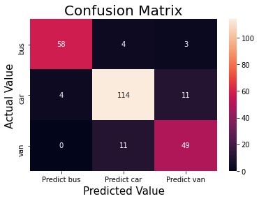

```python
cm = confusion_matrix(y_test_pca, y_pred_H_pca, labels=[0,1,2])
# Printing the precision and recall, among other metrics
df_cm = pd.DataFrame(cm, index = [i for i in ['bus', 'car', 'van']],
                  columns = ["Predict "+ str(i) for i in ['bus', 'car', 'van']])
sns.heatmap(df_cm, annot=True, fmt='g', );
plt.title('Confusion Matrix', fontsize = 20); # title with fontsize 20
plt.xlabel('Predicted Value', fontsize = 15); # x-axis label with fontsize 15
plt.ylabel('Actual Value', fontsize = 15);
```

```python
print(classification_report(y_test_pca, y_pred_H_pca, labels=[0,1,2]))
```

```
              precision    recall  f1-score   support

           0       0.94      0.89      0.91        65
           1       0.88      0.88      0.88       129
           2       0.78      0.82      0.80        60

    accuracy                           0.87       254
   macro avg       0.87      0.86      0.86       254
weighted avg       0.87      0.87      0.87       254
```

### F1_score

```python
f1 = f1_score(y_test_pca, y_pred_H_pca,average="weighted")
f1
```

```
0.8707675464131416
```

### After hypertuning my model is predicting 87% Accuracy with 5 features

```python
result.append(['SVC With HyperTuning with Balanced PC', train_accuracy, test_accuracy,auc,f1])
```

```python
def compareConfusionMatrix(y_test, y_pre_sc, y_pre_pca, y_pre_h_pca):
    fig,axs = plt.subplots(nrows=1, ncols=3, figsize=(15,4))
    cm = confusion_matrix(y_test, y_pre_sc, labels=[0,1,2])
    df_cm = pd.DataFrame(cm, index = [i for i in ['bus', 'car', 'van']],
                  columns = ["Predict "+ str(i) for i in ['bus', 'car', 'van']])
    axs[0].set_title('CM for Balanced Scale Dataset')
    axs[0].set_xlabel('Predicted')
    axs[0].set_ylabel('Original')
    sns.heatmap(df_cm, annot=True, fmt='g',ax=axs[0]);


    cm = confusion_matrix(y_test, y_pre_pca, labels=[0,1,2])
    df_cm = pd.DataFrame(cm, index = [i for i in ['bus', 'car', 'van']],
                  columns = ["Predict "+ str(i) for i in ['bus', 'car', 'van']])
    #plt.figure(figsize = (7,5))
    axs[1].set_xlabel('Predicted')
    axs[1].set_ylabel('Original')
    axs[1].set_title('CM for Balanced PCA Dataset')
    sns.heatmap(df_cm, annot=True, fmt='g',ax=axs[1])



    cm = confusion_matrix(y_test, y_pre_h_pca, labels=[0,1,2])
    df_cm = pd.DataFrame(cm, index = [i for i in ['bus', 'car', 'van']],
                  columns = ["Predict "+ str(i) for i in ['bus', 'car', 'van']])
    #plt.figure(figsize = (7,5));
    axs[2].set_xlabel('Predicted')
    axs[2].set_ylabel('Original')
    sns.heatmap(df_cm, annot=True, fmt='g',ax=axs[2]);
    axs[2].set_title('CM for hypertuned Balanced PCA Dataset');
```

```python
pd.DataFrame(result, columns=['Model', 'Train Accuracy', 'Test Accuracy','AUC','f1-score'])
```

|  | Model | Train Accuracy | Test Accuracy | AUC | f1-score |
| --- | --- | --- | --- | --- | --- |
| 0 | SVC with Balanced Scaled Data | 0.981111 | 0.944882 | 0.995521 | 0.945242 |
| 1 | SVC with Balanced PCA | 0.924444 | 0.881890 | 0.978024 | 0.883548 |
| 2 | SVC With HyperTuning with Balanced PC | 0.978889 | 0.870079 | 0.954071 | 0.870768 |

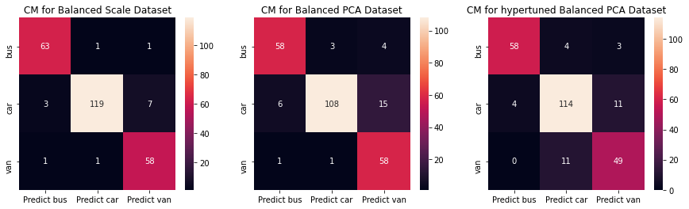

```python
compareConfusionMatrix(y_test, y_pred_bal_scle,y_pred_pca,  y_pred_H_pca)
```

### Prediction capability is reduced for VAN and bus. Emsemble technical will give better result.

### Showing overfitting of data in the model

### 5. Data Understanding & Cleaning:

## A. Explain pre-requisite/assumptions of PCA.

### 1) PCA assumes a correlation between features.

#### If the features (or dimensions or columns, in tabular data) are not correlated, PCA will be unable to determine principal components.

### 2) PCA is sensitive to the scale of the features.

#### Imagine we have two features - one takes values between 0 and 1000, while the other takes values between 0 and 1. PCA will be extremely biased towards the first feature being the first principle component, regardless of the actual maximum variance within the data. This is why it’s so important to standardize the values first.

### 3) PCA is not robust against outliers.

#### Similar to the point above, the algorithm will be biased in datasets with strong outliers. This is why it is recommended to remove outliers before performing PCA.

### 4)PCA assumes a linear relationship between features.

#### The algorithm is not well suited to capturing non-linear relationships. That’s why it’s advised to turn non-linear features or relationships between features into linear, using the standard methods such as log transforms.

### 5) Technical implementations often assume no missing values.

#### When computing PCA using statistical software tools, they often assume that the feature set has no missing values (no empty rows). Be sure to remove those rows and/or columns with missing values, or impute missing values with a close approximation (e.g. the mean of the column)

# B. Explain advantages and limitations of PCA.

### AdVantage:

### 1) Easy to compute:

##### PCA is based on linear algebra, which is computationally easy to solve by computers.

### 2) Speeds up other machine learning algorithms.

#### Machine learning algorithms converge faster when trained on principal components instead of the original dataset.

### 3) Counteracts the issues of high-dimensional data.

#### High-dimensional data causes regression-based algorithms to overfit easily. By using PCA beforehand to lower the dimensions of the training dataset, we prevent the predictive algorithms from overfitting.

### 4) There is no correlation between PCA.

### Limitation:

### 1) Low interpretability of principal components.

#### Principal components are linear combinations of the features from the original data, but they are not as easy to interpret. For example, it is difficult to tell which are the most important features in the dataset after computing principal components.

### 2) The trade-off between information loss and dimensionality reduction.

#### Although dimensionality reduction is useful, it comes at a cost. Information loss is a necessary part of PCA. Balancing the trade-off between dimensionality reduction and information loss is unfortunately a necessary compromise that we have to make when using PCA.